# Loading Tapestri Data

# Load data from various sources

Enable loading from various files.

- H5 is the future format for multi-omics and multi-samples, supporting DNA and DNA + Protein analysis.
- Loom supports only DNA mutation analysis.
- Insights export only supports DNA analysis.

## Load from Loom

Works only for DNA and single samples since loom files only contain 1 sample.

```r
filename <- system.file("extdata", "PE11.cells.loom", package = "TapestriR")

variants = read_loom(filename,min_mutation_rate = 0.05)

filtered_variants = filter_variants(variants,filetype="loom")
vaf=round(filtered_variants@data_layers$AD/filtered_variants@data_layers$DP, 3)
vaf[is.na(vaf)] <- 0
filtered_variants = add_data_layer(filtered_variants,'VAF',vaf)

filtered_variants
```

```
## Formal class 'Tapestri_Assay' [package "TapestriR"] with 6 slots
##   ..@ assay_name         : chr "dna"
##   ..@ metadata           :List of 1
##   .. ..$ cell_info: tibble [1 x 2] (S3: tbl_df/tbl/data.frame)
##   ..@ feature_annotations: tibble [8 x 11] (S3: tbl_df/tbl/data.frame)
##   ..@ cell_annotations   : tibble [5,043 x 3] (S3: tbl_df/tbl/data.frame)
##   ..@ data_layers        :List of 6
##   .. ..$ NGT: tibble [5,043 x 8] (S3: tbl_df/tbl/data.frame)
##   .. ..$ AD : tibble [5,043 x 8] (S3: tbl_df/tbl/data.frame)
##   .. ..$ DP : tibble [5,043 x 8] (S3: tbl_df/tbl/data.frame)
##   .. ..$ GQ : tibble [5,043 x 8] (S3: tbl_df/tbl/data.frame)
##   .. ..$ RO : tibble [5,043 x 8] (S3: tbl_df/tbl/data.frame)
##   .. ..$ VAF: tibble [5,043 x 8] (S3: tbl_df/tbl/data.frame)
##   ..@ analysis_layers    : list()
```

## Load multi-omics H5

Works for DNA and DNA + Protein data. Also works for multi-sample. Best practice is to create a multi-assay, multi-sample h5 in Pipeline, and apply filters before loading into R.

Usage: * Load multi-sample multi-omic h5 file * Filter and normalize assays

```r
filename <- system.file("extdata", "4_cell_line_mix_dna_protein.h5", package = "TapestriR")

experiment = read_tap(filename)

# Ideally, we would start by loading a filtered H5, but for now, we will load data with some basic filters.
filtered_variants = filter_variants(experiment$assays$dna_variants)
# Add the filtered data back to the experiment. This will be a subset of the rest of the assays to ensure that we have the same cells.
experiment = add_assay(moo = experiment,assay = filtered_variants, keep_common_cells = TRUE)

# Normalize using the clr method.
protein_counts_norm = experiment$assays$protein_read_counts$data_layers$read_counts %>% clr_by_feature() %>% as_tibble(rownames = NA)
# Add normalized data to the protein assay.
experiment$assays$protein_read_counts = add_data_layer(experiment$assays$protein_read_counts,'normalized',protein_counts_norm)


normalized_dna_reads = normalize_dna_reads(experiment$assays$dna_read_counts$data_layers$read_counts)
experiment$assays$dna_read_counts = add_data_layer(experiment$assays$dna_read_counts,'normalized',normalized_dna_reads)


experiment
```

```
## Experiment: 4_cell_line_mix_dna_protein.h5
## Num Cells: 1236
## Formal class 'Tapestri_Assay' [package "TapestriR"] with 6 slots
##   ..@ assay_name         : chr "dna_read_counts"
##   ..@ metadata           :List of 1
##   ..@ feature_annotations: tibble [127 x 6] (S3: tbl_df/tbl/data.frame)
##   ..@ cell_annotations   : tibble [1,236 x 4] (S3: tbl_df/tbl/data.frame)
##   ..@ data_layers        :List of 2
##   ..@ analysis_layers    : list()
## Formal class 'Tapestri_Assay' [package "TapestriR"] with 6 slots
##   ..@ assay_name         : chr "dna_variants"
##   ..@ metadata           :List of 1
##   ..@ feature_annotations: tibble [44 x 10] (S3: tbl_df/tbl/data.frame)
##   ..@ cell_annotations   : tibble [1,236 x 5] (S3: tbl_df/tbl/data.frame)
##   ..@ data_layers        :List of 5
##   ..@ analysis_layers    : list()
## Formal class 'Tapestri_Assay' [package "TapestriR"] with 6 slots
##   ..@ assay_name         : chr "protein_read_counts"
##   ..@ metadata           :List of 1
##   ..@ feature_annotations: tibble [10 x 1] (S3: tbl_df/tbl/data.frame)
##   ..@ cell_annotations   : tibble [1,236 x 4] (S3: tbl_df/tbl/data.frame)
##   ..@ data_layers        :List of 2
##   ..@ analysis_layers    : list()
```

## Create your own multiomics object

Build a multiomics object from individual components instead of using the `read_tap` function.

- Load variant assay and filter.
- Load Protein assay and normalize.
- Load DNA read counts.
- Create a multiomics object and merge all 3 assays. This will ensure each assay has the same cells.

```r
ASSAY_NAME_VARIANT = 'dna_variants'
ASSAY_NAME_PROTEIN = 'protein_read_counts'

filename <- system.file("extdata", "4_cell_line_mix_dna_protein.h5", package = "TapestriR")

# Ideally, we would start by loading a filtered H5, but for now, we will send a filtering list to the function to mimic it.
variants = read_assay_h5(filename = filename, assay_name = ASSAY_NAME_VARIANT, min_mutation_rate = 0.005)

filtered_variants = filter_variants(variants)
# Load the protein assay and normalize.
protein = read_assay_h5(filename = filename, assay_name = ASSAY_NAME_PROTEIN)
# Normalize using the clr method.
protein_counts_norm = protein@data_layers$read_counts %>% clr_by_feature() %>% as_tibble(rownames = NA)
# Add normalized data to the protein assay.
protein = add_data_layer(protein,'normalized',protein_counts_norm)

# Create a multiomics object (moo).
experiment = create_moo(experiment_name = basename(filename), cell_annotations = filtered_variants@cell_annotations)
experiment = add_assay(moo = experiment,assay = filtered_variants)
experiment = add_assay(experiment,protein, keep_common_cells = TRUE)

experiment
```

```
## Experiment: 4_cell_line_mix_dna_protein.h5
## Num Cells: 1236
## Formal class 'Tapestri_Assay' [package "TapestriR"] with 6 slots
##   ..@ assay_name         : chr "dna_variants"
##   ..@ metadata           :List of 1
##   ..@ feature_annotations: tibble [44 x 10] (S3: tbl_df/tbl/data.frame)
##   ..@ cell_annotations   : tibble [1,236 x 5] (S3: tbl_df/tbl/data.frame)
##   ..@ data_layers        :List of 5
##   ..@ analysis_layers    : list()
## Formal class 'Tapestri_Assay' [package "TapestriR"] with 6 slots
##   ..@ assay_name         : chr "protein_read_counts"
##   ..@ metadata           :List of 1
##   ..@ feature_annotations: tibble [10 x 1] (S3: tbl_df/tbl/data.frame)
##   ..@ cell_annotations   : tibble [1,236 x 4] (S3: tbl_df/tbl/data.frame)
##   ..@ data_layers        :List of 2
##   ..@ analysis_layers    : list()
```

### X-Y plots

1. Select the proteins to plot on the X and Y axes.
2. Select a set of other feature(s) to color the plot by. If you choose more than one feature, each feature will be plotted in a subplot.

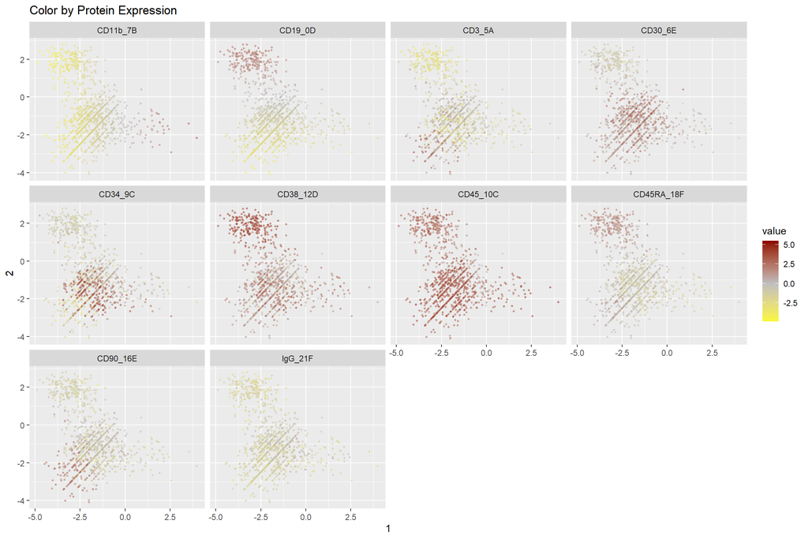

```r
##################
# Select the proteins to plot on X and Y.
##################

# protein_x = 'CD34'
# protein_y = 'CD38'

protein_x = 1
protein_y = 2

##################
# Select 1 or more features to color by.
# color_by should be a vector of the column header you want to color by.
##################

# All proteins
color_by = experiment$assays$protein_read_counts$data_layers$normalized

# Select a few proteins.
# color_by =  experiment$assays$protein_read_counts$data_layers$normalized %>% select('CD110','CD117')

# Select a few variants.
# color_by =  experiment$assays$dna_variants$data_layers$NGT %>% select(1:10) %>% mutate_all(as_factor) %>% mutate_all(recode_genotypes)


p  = tapestri_scatterplot(x = experiment$assays$protein_read_counts$data_layers$normalized[[protein_x]],
                 y= experiment$assays$protein_read_counts$data_layers$normalized[[protein_y]],
                 color_by = color_by)+ scale_colour_gradient2(low="yellow", mid='grey', high="darkred")
p = p + xlab(protein_x) + ylab(protein_y) + ggtitle('Color by Protein Expression')
p
```

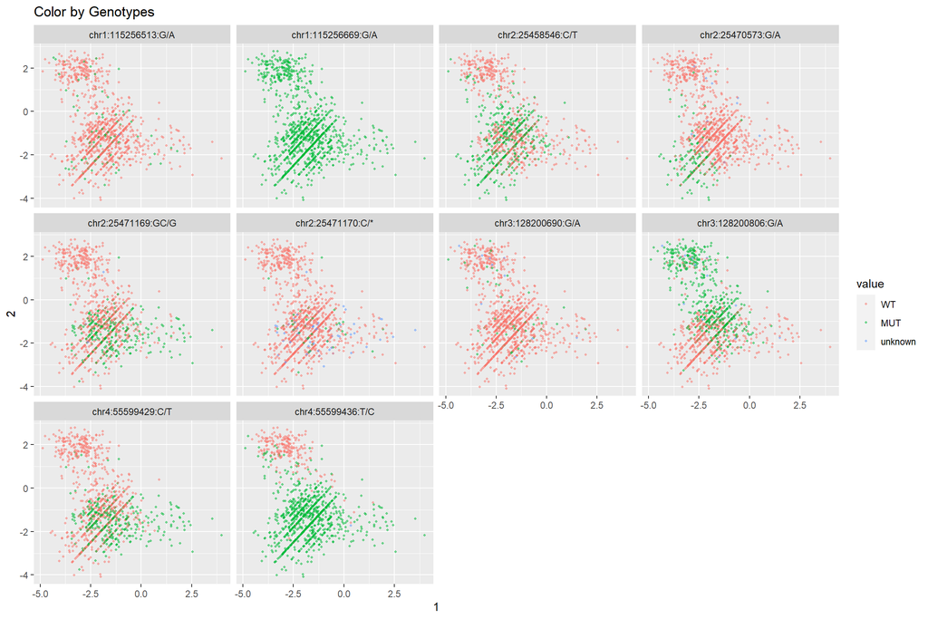

```r
# Select a few variants.
color_by =  experiment$assays$dna_variants$data_layers$NGT %>% select(1:10) %>% mutate_all(as_factor) %>% mutate_all(recode_genotypes)


p  = tapestri_scatterplot(x = experiment$assays$protein_read_counts$data_layers$normalized[[protein_x]],
                 y= experiment$assays$protein_read_counts$data_layers$normalized[[protein_y]],
                 color_by = color_by)
p = p + xlab(protein_x) + ylab(protein_y) + ggtitle('Color by Genotypes')
p
```

## Load the data from Tapestri Insights export

Works for DNA only. Export can be from a multi-sample project in Tapestri Insights.

Usage:

- Extract the exported zip file.
- Read directory to create a new `Tapestri_Assay` object.

```r
export_dir <- system.file("extdata", "insights_2.2_export", package = "TapestriR")

# Show files
dir(export_dir)
```

```
## [1] "AF.csv"       "DP.csv"       "GQ.csv"       "NGT.csv"      "README.txt"
## [6] "Variants.csv"
```

```r
variants = read_insights_export(export_dir = export_dir)
variants
```

```
## Formal class 'Tapestri_Assay' [package "TapestriR"] with 6 slots
##   ..@ assay_name         : chr "variants"
##   ..@ metadata           :List of 1
##   .. ..$ cell_info: tibble [1 x 2] (S3: tbl_df/tbl/data.frame)
##   ..@ feature_annotations: tibble [54 x 20] (S3: spec_tbl_df/tbl_df/tbl/data.frame)
##   ..@ cell_annotations   : tibble [7,023 x 3] (S3: tbl_df/tbl/data.frame)
##   ..@ data_layers        :List of 4
##   .. ..$ NGT: tibble [7,023 x 54] (S3: tbl_df/tbl/data.frame)
##   .. ..$ AF : tibble [7,023 x 54] (S3: tbl_df/tbl/data.frame)
##   .. ..$ DP : tibble [7,023 x 54] (S3: tbl_df/tbl/data.frame)
##   .. ..$ GQ : tibble [7,023 x 54] (S3: tbl_df/tbl/data.frame)
##   ..@ analysis_layers    :List of 1
##   .. ..$ Subclone: tibble [7,023 x 1] (S3: tbl_df/tbl/data.frame)
```